# Использование конхиологического признака для определения видов мидий

Вадим Хайтов

20 января 2019 г

Определим корректное определение вида за счет морфологического признака, как событие, при котором произошло совпадение морфотипа и вида. То есть мидия, которая по морфологическому признаку была определена, как T-морфотип, при корректном определении должна иметь генотип, соответствующий M.trossulus (MT), а мидия E-морфотипа,должна иметь генотип, соответствующих M.edulis (ME). Такие события будут маркироваться 1, а альтернативное событие (неправильное определение), как 0.

Задача: Установить как зависит вероятность корректного определения вида мидии по ее морфотипу от параметров, доступных для экспресс-оценки в полевых условиях. К числу таких параметров относятся: уровень солености, частота одного из двух альтернативных морфотипов (T- или E-морфотип) и, собственно, морфотипа.

## Подготавливаем данные

```r
library(lme4)
library(ggplot2)
library(reshape2)
library(sjstats)
library(dplyr)
library(car)
library(doBy)



# Подготовка данных

myt <- read.table("data_salinity2.csv", header = T, sep = ",")

myt$Sp [myt$str > 0.5] <- "M.trossulus" #Лучше обозначать так!
myt$Sp [myt$str <= 0.5] <- "M.edulis"
myt$Sp <- factor(myt$Sp)


myt$sal_place <- factor(myt$sal_place, levels = c("low", "meadle", "high"))
myt$sal_place2 <- ifelse(myt$sal_place == "low", "fresh", "normal")



myt2 <- myt[!is.na(myt$size), ]

myt2 <- myt2[!is.na(myt2$ind), ]


# переменная congr - это событие правильного определения 1 если T-морфотип совпадает с MT и E-морфотип совпадает с ME, 0 - если не свопадает

myt2$congr <- ifelse((myt2$ind == 1 & myt2$Sp == "M.trossulus") | (myt2$ind == 0 & myt2$Sp == "M.edulis"), 1, 0   )



ind_pop <-summaryBy(ind ~ pop, data = myt2)

names(ind_pop) <- c("pop", "freq_Tmorph")

myt2 <- merge(myt2, ind_pop, by = "pop")


myt2$morph <- ifelse(myt2$ind == 1, "T_m", "E_m")
myt2$morph <- factor(myt2$morph)
```

##vОценки значений предикторов

**Морфотип** - бинарная переменная с двумя градациями T-морфотип и E-морфотип в соответствии со степенью развития перламутрового слоя в районе лигамента.

**Частота одного из морфотипов:** Оценивается, как доля мидий T-морфотипа в общем количестве моллюсков, собранных в данном локальном поселении.

**Соленость** Все локальные выборки были разбиты на несколько 5 групп, приблизительно соответствующие градиенту солености.

Для дальнейшего анализа введем дискретный фактор `place2` со следующими градациями.

```r
myt2$place2 <- factor(myt2$place2, levels = c( "kand_cut" , "kand_main", "kola_cut"  ,  "kola_tuva", "kola_dz"))
```

Характер связи этих выделов с соленостью демонстрирует следующий рисунок.

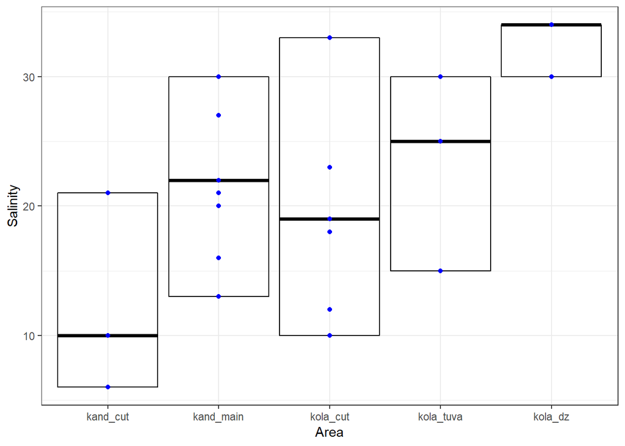

```r
# stat_sum_df <- function(fun, geom="crossbar", ...) {
#   stat_summary(fun.data = fun, geom = geom, width = 0.2, ...)
# }

ggplot(myt2, aes(x = place2, y = sal_low)) + stat_summary(fun.data = "median_hilow", mapping = aes(group = place2), geom="crossbar") + theme_bw() + labs(x = "Area", y = "Salinity") + geom_point(color ="blue")
```

Итого, видно, что пять выделов демонстрируют некоторый градиент: опресненный кут Кандалакшского залива -> области со средней соленостью (основная акватория Кандалакшского залива и кут Кольского залива) -> Область с достаточно высокой соленостью (г.Тюва) -> участок с нормальной океанической соленостью (Дальние Зеленцы). Поскольку строгое определение солености не проводилось, то для ее оценки будем использовать дискретный фактор.

При этом явного градиента в доле мидий T-морфотипа в этом ряду не наблюдается.

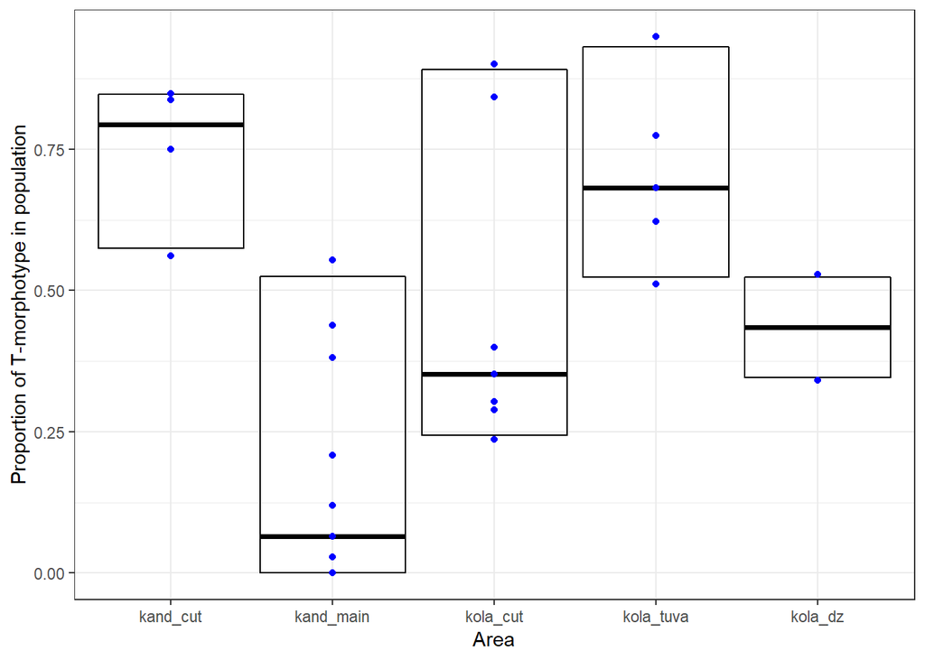

```r
props <- summaryBy(freq_Tmorph + freq_MT  ~ pop + place2, data = myt2)
ggplot(props, aes(x = place2, y = freq_Tmorph.mean)) + stat_summary(fun.data = "median_hilow", mapping = aes(group = place2), geom="crossbar") + theme_bw() + labs(x = "Area", y = "Proportion of T-morphotype in population") + geom_point(color ="blue")
```

На всякий случай проверяем на наличие мультиколлинеарности предикторов.

```r
vif(glm(congr ~ morph + place2 + freq_Tmorph, family = "binomial", data = myt2))
```

```
##                 GVIF Df GVIF^(1/(2*Df))
## morph       1.327307  1        1.152088
## place2      1.972626  4        1.088631
## freq_Tmorph 2.316027  1        1.521850
```

В легкой степени она присутствует, но в допустимых пределах (считается что VIF > 3 это не есть хорошо, 2 <VIF< 3 - нормально).

## Модель

Поскольку никакой особой гипотезы у нас нет, то модель будет включать все возможные взаимодействия.

```r
Mod_fT_congr <- glmer(congr ~ morph * place2 * freq_Tmorph  + (1 | pop), data = myt2, family = "binomial", control=glmerControl(optimizer="bobyqa",optCtrl=list(maxfun=2e5)))

Anova(Mod_fT_congr)
```

```
## Analysis of Deviance Table (Type II Wald chisquare tests)
##
## Response: congr
##                            Chisq Df Pr(>Chisq)
## morph                    16.5701  1  4.688e-05 ***
## place2                   13.3863  4  0.0095346 **
## freq_Tmorph               4.3317  1  0.0374082 *
## morph:place2             94.6576  4  < 2.2e-16 ***
## morph:freq_Tmorph        14.4210  1  0.0001462 ***
## place2:freq_Tmorph        8.2185  4  0.0838948 .
## morph:place2:freq_Tmorph 32.8699  4  1.270e-06 ***
## ---
## Signif. codes:  0 '***' 0.001 '**' 0.01 '*' 0.05 '.' 0.1 ' ' 1
```

Модель упростить нельзя.

## Диагностика

```r
overdisp(Mod_fT_congr)
```

```
##
## # Overdispersion test
##
##        dispersion ratio = 0.9700
##   Pearson's Chi-Squared = 1705.2514
##                 p-value = 0.8126
```

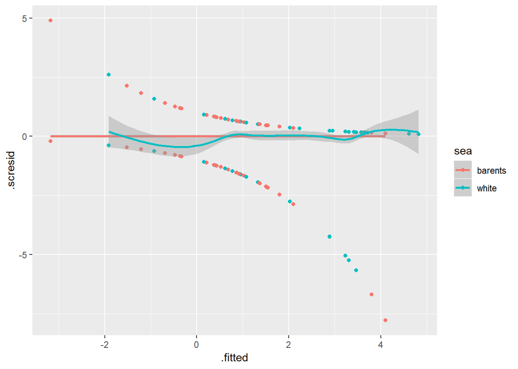

```r
Mod_fT_congr_diagn <- fortify(Mod_fT_congr)


ggplot(Mod_fT_congr_diagn, aes(x = .fitted, y = .scresid, color = sea)) + geom_point() + geom_smooth()
```

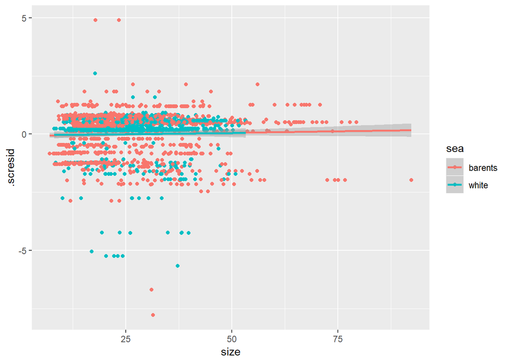

```r
ggplot(Mod_fT_congr_diagn, aes(x = size, y = .scresid, color = sea)) + geom_point() + geom_smooth(method = "lm")
```

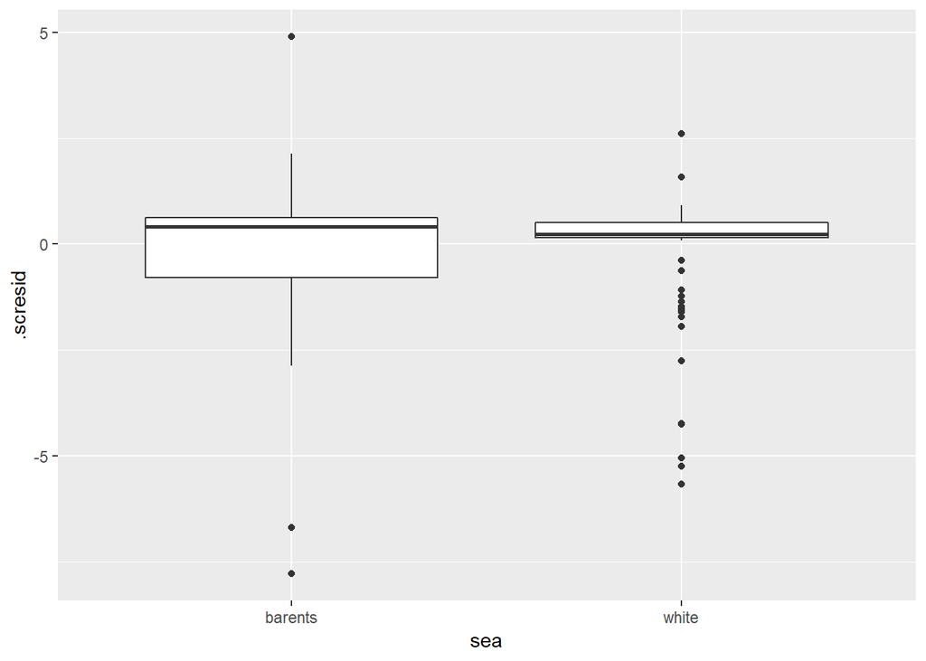

```r
ggplot(Mod_fT_congr_diagn, aes(x = sea, y = .scresid)) + geom_boxplot()
```

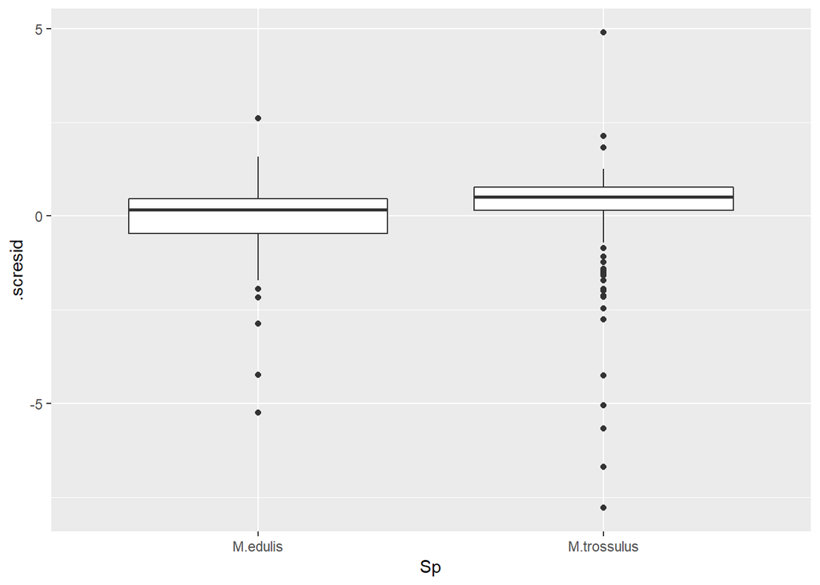

```r
ggplot(Mod_fT_congr_diagn, aes(x = Sp, y = .scresid)) + geom_boxplot()
```

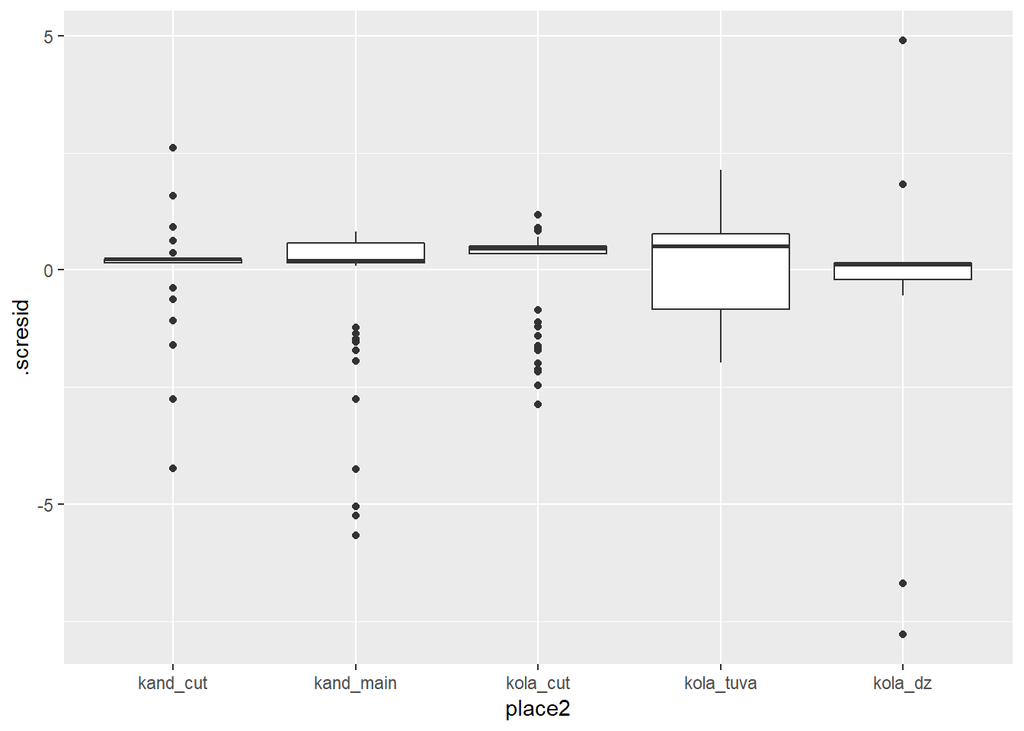

```r
ggplot(Mod_fT_congr_diagn, aes(x = place2, y = .scresid)) + geom_boxplot()
```

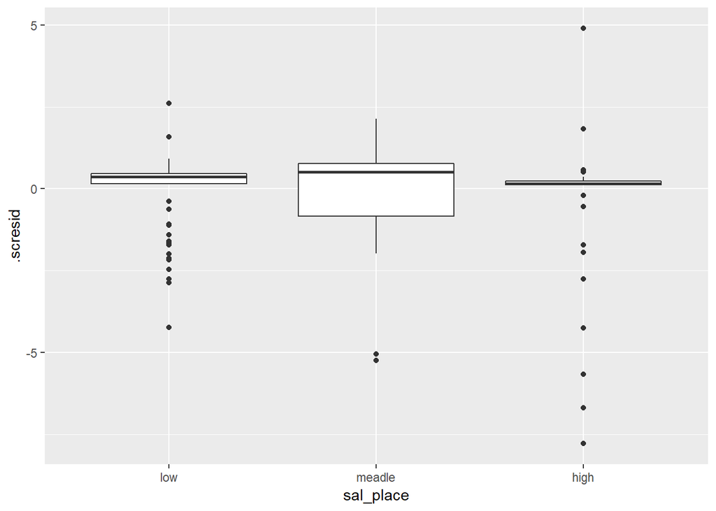

```r
ggplot(Mod_fT_congr_diagn, aes(x = sal_place, y = .scresid)) + geom_boxplot()
```

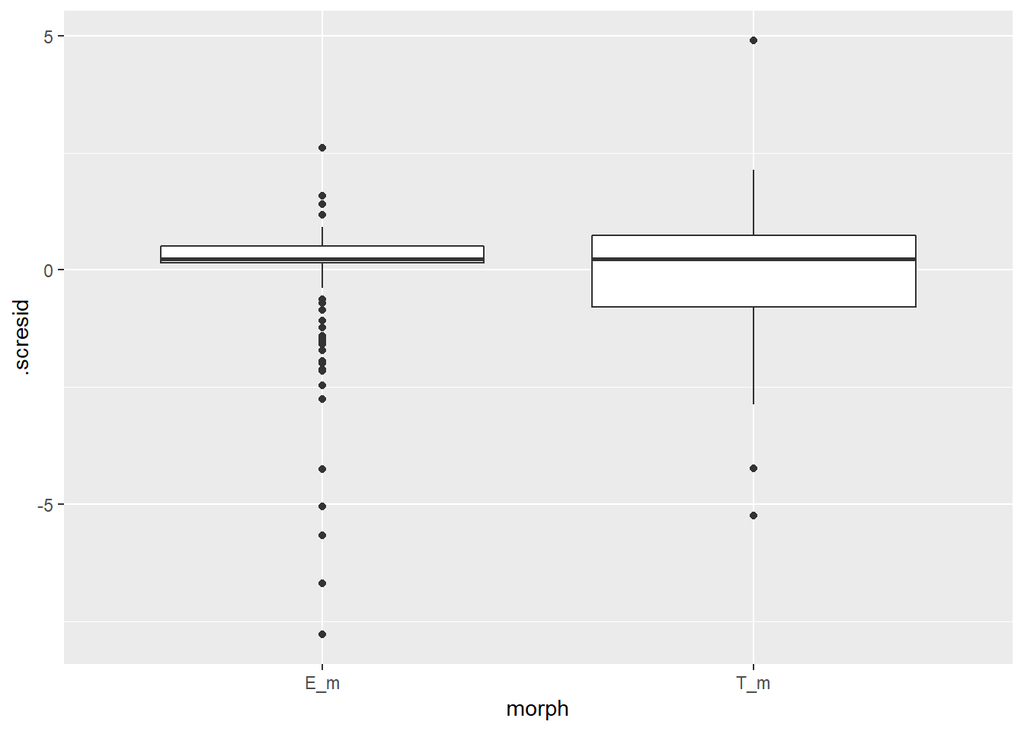

```r
ggplot(Mod_fT_congr_diagn, aes(x = morph, y = .scresid)) + geom_boxplot()
```

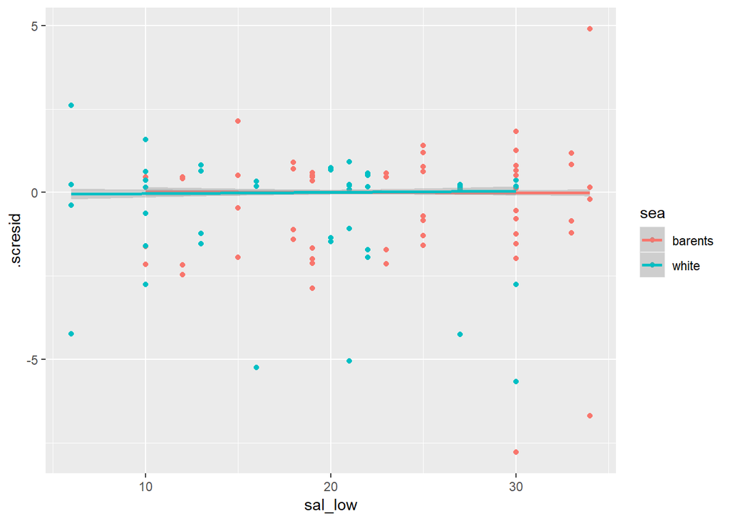

```r
ggplot(Mod_fT_congr_diagn, aes(x = sal_low, y = .scresid, color = sea)) + geom_point() + geom_smooth(method = "lm")
```

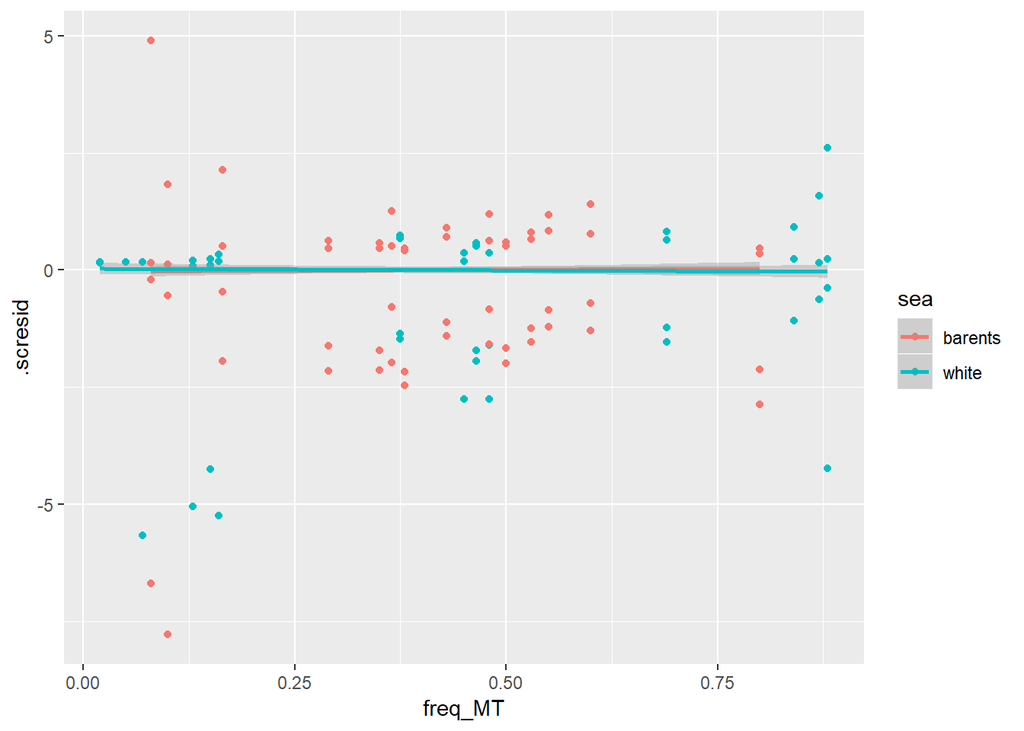

```r
ggplot(Mod_fT_congr_diagn, aes(x = freq_MT, y = .scresid, color = sea)) + geom_point() + geom_smooth(method = "lm")
```

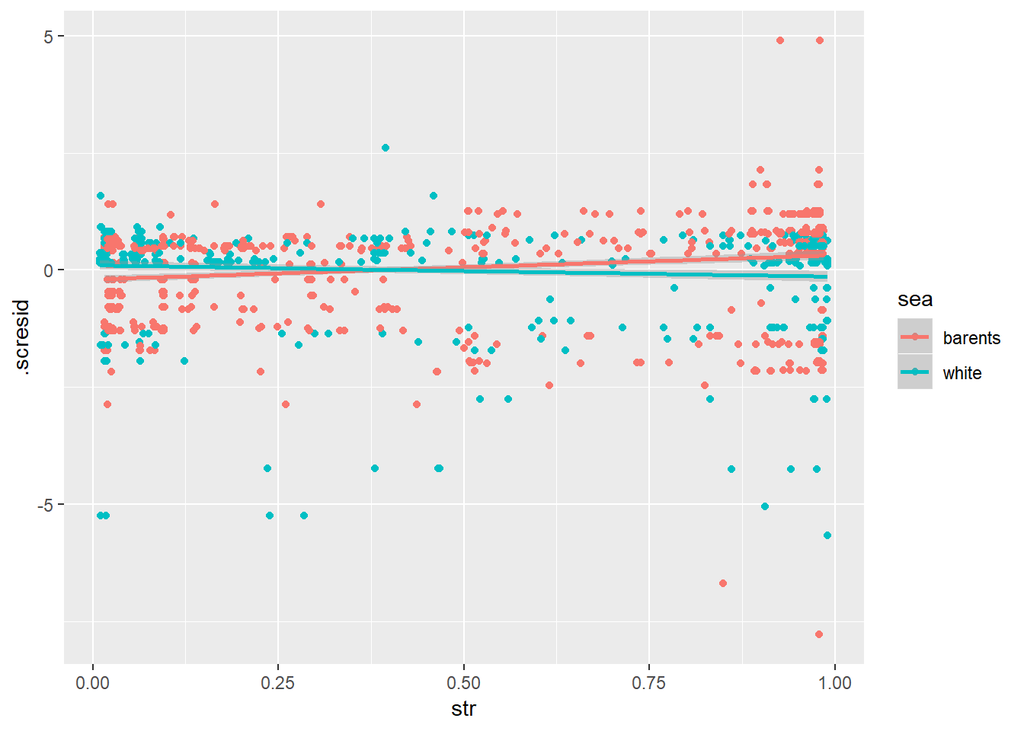

```r
ggplot(Mod_fT_congr_diagn, aes(x = str, y = .scresid, color = sea)) + geom_point() + geom_smooth(method = "lm")
```

Итого. Не все идеально, но и не ужасно.

Смущает в основном паттерн, связанный со `str` (см. последний график). Как трактовать этот паттерн? Точно ли это нормальная идея, проводить границы между видами по str = 0.5 в обеих морях? Я бы сказал,глядя на этот график, что граница между видами в разных регионах должна проводиться по разным значениям structure.

На всякий случай вот так выглядит частотное распределение structure в каждом из регионов.

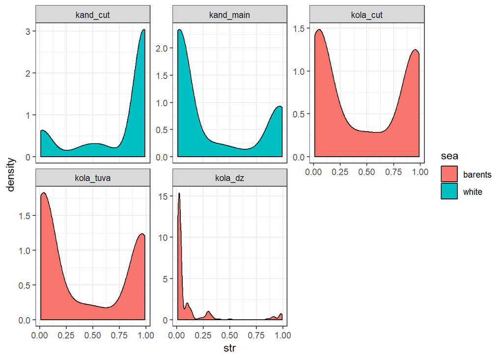

```r
ggplot(myt2, aes(x = str, fill = sea)) + geom_density() + theme_bw() + facet_wrap(~place2, scales = "free_y")
```

## Визуализация модели

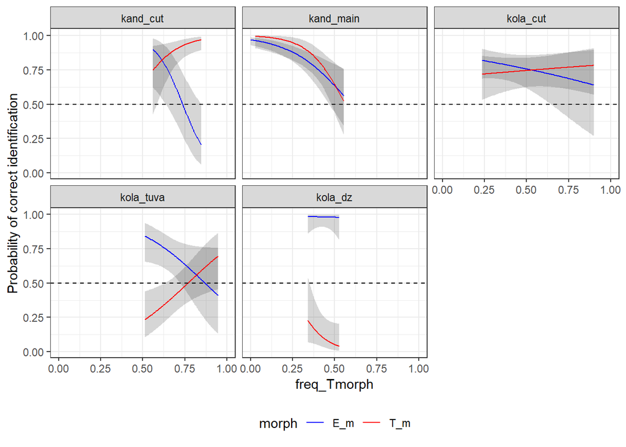

```r
newdata <- myt2 %>% group_by(place2, morph) %>% do(data.frame(freq_Tmorph = seq(min(.$freq_Tmorph), max(.$freq_Tmorph), length.out = 100)))

newdata$fit <- predict(Mod_fT_congr, newdata = newdata, type = "response", re.form = NA)

newdata$fit_eta <- predict(Mod_fT_congr, newdata = newdata, re.form = NA)


X <- model.matrix(  ~ morph *place2 * freq_Tmorph , data = newdata)



b <- fixef(Mod_fT_congr)



newdata$se_eta <- sqrt(diag(X %*% vcov(Mod_fT_congr) %*% t(X)))

logit_back <- function(x) exp(x)/(1 + exp(x)) # обратная логит-трансформация



newdata$lwr <- logit_back(newdata$fit_eta - 2 * newdata$se_eta)
newdata$upr <- logit_back(newdata$fit_eta + 2 * newdata$se_eta)



Pl_fit <- ggplot(newdata, aes(x = freq_Tmorph, y = fit)) + geom_ribbon(aes(ymin = lwr, ymax = upr, group = morph), alpha = 0.2)  + geom_line(aes(color = morph)) + facet_wrap( ~ place2) + scale_color_manual(values = c("blue", "red")) + theme_bw() + xlim(0,1) + geom_hline(yintercept = 0.5, linetype = 2 ) + labs(y = "Probability of correct identification") + theme(legend.position = "bottom")

Pl_fit
```

Наносим “первичные данные” - это доля корректно определенных мидий в каждой из популяций (в пределах каждого из морфотипов).

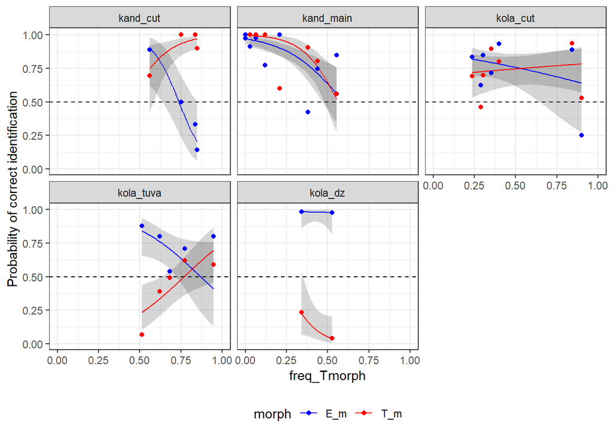

```r
correct_prop <- summaryBy(congr + freq_Tmorph  ~ pop + place2 + morph, data = myt2)

Pl_fit + geom_point(data = correct_prop, aes(x = freq_Tmorph.mean, y = congr.mean, color = morph))
```

Если считать, что вероятность правильной идентификации, меньше 0.5 нас не устраивает, то выводы из полученной картинки могут быть следующие.

1. В условиях сильного опреснения (кут Кандалакшского залива). Идентифицировать М.trossulus, используя T-морфотип в качестве маркера мы можем везде. Однако идентификация M.edulis по E-морфотипу возможна только в тех местах, где доля T-морфотипа в поселении не превосходит 0.75.
2. В условиях средней солености, но вдалеке от океанического побережья (основная часть Кандалакшского залива, кут Кольского залива). Мы можем свободно использовать морфотипы для идентификации видов. Более точная идентификация будет идти в Белом море, но опять же если доля T-морфотипа не очень велика. В куту Кольского залива точность идентификации немного ниже. При этом важно отметить, что в этих двух выделах оба морфотипа дают более или менее одинаковое качество определения.
3. Вероятно, какие-то ключевые “перестройки” происходят по мере приближения к открытому океаническому побережью. В районе г. Тюва надежно идентифицировать можно только M.edulis, используя E-морфотип в качестве маркера вида. Использовать T-морфотип в качестве маркера M.trossulus можно только если в популяции доля T-морфотипа очень высока (более 80-90%). Эта тенденция усугубляется в районе Дальних зеленцов. Здесь вообще нельзя идентифицировать M.trossulus по морфологическому маркеру. Однако если, мидия имеет E-морфотип, то она практически наверняка будет M.edulis.
4. Если наблюдаемая картина - это отражение влияния солености, то закономерность может быть сформулирована так. В условиях пониженной солености мы, используя соответствующий морфотип, надежно сможем определить только M.trossulus, а в условиях океанической солености - только M.edulis.

Этот результат можно генерализовать в виде следующей таблицы.

| Соленость | E-морфотип | T-морфотип |
| --- | --- | --- |
| Низкая (возможно, эстуарии крупных рек) | ? | M.trossulus |
| Средняя | M.edulis | M.trossulus |
| Высокая, близкая к океанической | M.edulis | ? |

Здесь всесто первичных данных точки отражают частоту M.trossulus в популяциях. Видно, что во всех местах чем больше доля T-морфотипа, тем выше часта M.trossulus. За исключением Дальних Зеленцов.

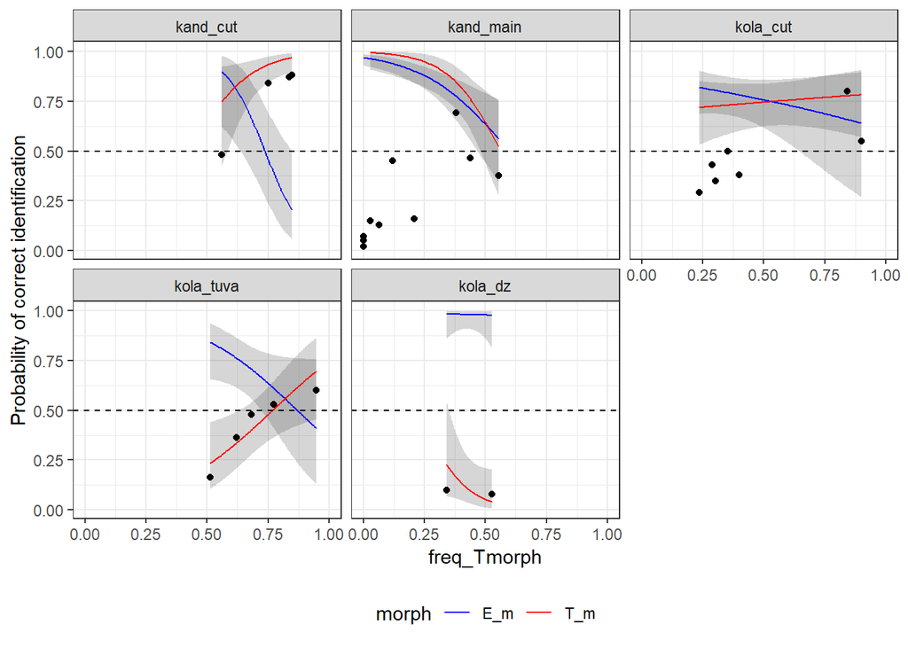

```r
Pl_fit + geom_point(data = props, aes(x = freq_Tmorph.mean, y = freq_MT.mean))
```

```r
props[props$place2 == "kola_cut",]
```

```
##        pop   place2 freq_Tmorph.mean freq_MT.mean
## 1    abram kola_cut        0.2888889         0.43
## 3    belok kola_cut        0.3030303         0.35
## 8       fr kola_cut        0.2363636         0.29
## 10   kuvsh kola_cut        0.9000000         0.55
## 13 nm_last kola_cut        0.4000000         0.38
## 19   sevsk kola_cut        0.3518519         0.50
## 29    zmis kola_cut        0.8421053         0.80
```

А отсюда сомнения.

## Сомнения

А кто сказал, что это соленость? Может быть это близость к гнезду вида.

Например, гнездо-гнездо M.trossulus в Кандалакшском заливе приурочено к опресненному куту (гнездышки в Умбе не считаем), а в Баренцевом море гнездо-гнездо M.edulis - это океанические побережья, типа Зеленцов.